# Covid 19 analysis

Jie Shen

2023-09-24

## File and Data

This is a R Markdown document for **COVID 19 project for China**. The data used in this project can be found at “https://github.com/CSSEGISandData/COVID-19/tree/master/csse_covid_19_data/csse_covid_19_time_series”. Please visit the site for detailed data description.

The data I used are global cases and deaths. From the website “https://github.com/CSSEGISandData/COVID-19”, Johns Hopkins Corona virus Resource Center ceased its collecting and reporting of global COVID-19 data on March 10, 2023. The global data is from World Health Organization (WHO) “https://www.who.int/”.

## Project goal

The project is to discover patterns and trends from COVID data in China. I want to explore things like the COVID cases and deaths trends over the years, and what states are best and worst.

## Packages needed

Be sure the following packages are installed first:

- tidyverse
- ggplot2
- caret
- lubridate

## Load Packages

```r
library(tidyverse)
library(ggplot2)
library(forcats)
library(lubridate)
library(dplyr)
library(caret)
```

## Import Data and clean up

```r
#Import data from webnsite
url_in<-"https://raw.githubusercontent.com/CSSEGISandData/COVID-19/master/csse_covid_19_data/csse_covid_19_time_series/"
file_names<-c("time_series_covid19_confirmed_global.csv","time_series_covid19_deaths_global.csv")

urls=str_c(url_in, file_names)
global_cases<-read_csv(urls[1])
global_deaths<-read_csv(urls[2])
```

Now let’s take a look and do some clean up

```r
# Take a look
head(global_cases)
```

```
## # A tibble: 6 × 1,147
##   `Province/State` `Country/Region`   Lat  Long `1/22/20` `1/23/20` `1/24/20`
##   <chr>            <chr>            <dbl> <dbl>     <dbl>     <dbl>     <dbl>
## 1 <NA>             Afghanistan       33.9 67.7          0         0         0
## 2 <NA>             Albania           41.2 20.2          0         0         0
## 3 <NA>             Algeria           28.0  1.66         0         0         0
## 4 <NA>             Andorra           42.5  1.52         0         0         0
## 5 <NA>             Angola           -11.2 17.9          0         0         0
## 6 <NA>             Antarctica       -71.9 23.3          0         0         0
## # ℹ 1,140 more variables: `1/25/20` <dbl>, `1/26/20` <dbl>, `1/27/20` <dbl>,
## #   `1/28/20` <dbl>, `1/29/20` <dbl>, `1/30/20` <dbl>, `1/31/20` <dbl>,
## #   `2/1/20` <dbl>, `2/2/20` <dbl>, `2/3/20` <dbl>, `2/4/20` <dbl>,
## #   `2/5/20` <dbl>, `2/6/20` <dbl>, `2/7/20` <dbl>, `2/8/20` <dbl>,
## #   `2/9/20` <dbl>, `2/10/20` <dbl>, `2/11/20` <dbl>, `2/12/20` <dbl>,
## #   `2/13/20` <dbl>, `2/14/20` <dbl>, `2/15/20` <dbl>, `2/16/20` <dbl>,
## #   `2/17/20` <dbl>, `2/18/20` <dbl>, `2/19/20` <dbl>, `2/20/20` <dbl>, …
```

```r
head(global_deaths)
```

```
## # A tibble: 6 × 1,147
##   `Province/State` `Country/Region`   Lat  Long `1/22/20` `1/23/20` `1/24/20`
##   <chr>            <chr>            <dbl> <dbl>     <dbl>     <dbl>     <dbl>
## 1 <NA>             Afghanistan       33.9 67.7          0         0         0
## 2 <NA>             Albania           41.2 20.2          0         0         0
## 3 <NA>             Algeria           28.0  1.66         0         0         0
## 4 <NA>             Andorra           42.5  1.52         0         0         0
## 5 <NA>             Angola           -11.2 17.9          0         0         0
## 6 <NA>             Antarctica       -71.9 23.3          0         0         0
## # ℹ 1,140 more variables: `1/25/20` <dbl>, `1/26/20` <dbl>, `1/27/20` <dbl>,
## #   `1/28/20` <dbl>, `1/29/20` <dbl>, `1/30/20` <dbl>, `1/31/20` <dbl>,
## #   `2/1/20` <dbl>, `2/2/20` <dbl>, `2/3/20` <dbl>, `2/4/20` <dbl>,
## #   `2/5/20` <dbl>, `2/6/20` <dbl>, `2/7/20` <dbl>, `2/8/20` <dbl>,
## #   `2/9/20` <dbl>, `2/10/20` <dbl>, `2/11/20` <dbl>, `2/12/20` <dbl>,
## #   `2/13/20` <dbl>, `2/14/20` <dbl>, `2/15/20` <dbl>, `2/16/20` <dbl>,
## #   `2/17/20` <dbl>, `2/18/20` <dbl>, `2/19/20` <dbl>, `2/20/20` <dbl>, …
```

```r
# Need to pivot dates to rows
global_cases<-global_cases %>%
  pivot_longer(cols= -c("Province/State", "Country/Region", Lat, Long),
                       names_to="date",
                       values_to="cases")
head(global_cases)
```

```
## # A tibble: 6 × 6
##   `Province/State` `Country/Region`   Lat  Long date    cases
##   <chr>            <chr>            <dbl> <dbl> <chr>   <dbl>
## 1 <NA>             Afghanistan       33.9  67.7 1/22/20     0
## 2 <NA>             Afghanistan       33.9  67.7 1/23/20     0
## 3 <NA>             Afghanistan       33.9  67.7 1/24/20     0
## 4 <NA>             Afghanistan       33.9  67.7 1/25/20     0
## 5 <NA>             Afghanistan       33.9  67.7 1/26/20     0
## 6 <NA>             Afghanistan       33.9  67.7 1/27/20     0
```

```r
# Do similar things to global deaths
global_deaths<-global_deaths %>%
  pivot_longer(cols= -c("Province/State", "Country/Region", Lat, Long),
                       names_to="date",
                       values_to="deaths")

# Combine global cases and deaths
global<- global_cases %>%
        full_join(global_deaths) %>%
        mutate(date=mdy(date)) %>%
        rename(Country_Region='Country/Region',
               Province_State ='Province/State')
```

[output not shown]

```r
# Summary statistics
summary(global)
```

```
##  Province_State     Country_Region          Lat               Long
##  Length:330327      Length:330327      Min.   :-71.950   Min.   :-178.12
##  Class :character   Class :character   1st Qu.:  3.934   1st Qu.: -42.60
##  Mode  :character   Mode  :character   Median : 21.513   Median :  20.94
##                                        Mean   : 19.719   Mean   :  22.18
##                                        3rd Qu.: 40.464   3rd Qu.:  90.36
##                                        Max.   : 71.707   Max.   : 178.06
##                                        NA's   :2286      NA's   :2286
##       date                cases               deaths
##  Min.   :2020-01-22   Min.   :        0   Min.   :      0
##  1st Qu.:2020-11-02   1st Qu.:      680   1st Qu.:      3
##  Median :2021-08-15   Median :    14429   Median :    150
##  Mean   :2021-08-15   Mean   :   959384   Mean   :  13380
##  3rd Qu.:2022-05-28   3rd Qu.:   228517   3rd Qu.:   3032
##  Max.   :2023-03-09   Max.   :103802702   Max.   :1123836
##
```

We can see the earliest date is 2020-01-22 and the latest is 2023-03-09.

Since it’s unfair to compare the numbers from big population state to a small state, I also want to see cases and deaths per populations. I found the population data set on the same github website.

```r
# Import population data
uid_lookup_url="https://raw.githubusercontent.com/CSSEGISandData/COVID-19/master/csse_covid_19_data/UID_ISO_FIPS_LookUp_Table.csv"
uid=read_csv(uid_lookup_url)
# After looking through the columns, exclude unwanted columns
uid<-uid%>% select(-c(Lat, Long_, Combined_Key, iso2,  iso3,  code3,Admin2, UID, FIPS) )

# Add population column to global data
global<-global%>%
  full_join(uid, by=c("Province_State", "Country_Region"))

# Get China data
CN<-global%>%filter(Country_Region=="China")
head(CN)
```

```
## # A tibble: 6 × 8
##   Province_State Country_Region   Lat  Long date       cases deaths Population
##   <chr>          <chr>          <dbl> <dbl> <date>     <dbl>  <dbl>      <dbl>
## 1 Anhui          China           31.8  117. 2020-01-22     1      0   61027171
## 2 Anhui          China           31.8  117. 2020-01-23     9      0   61027171
## 3 Anhui          China           31.8  117. 2020-01-24    15      0   61027171
## 4 Anhui          China           31.8  117. 2020-01-25    39      0   61027171
## 5 Anhui          China           31.8  117. 2020-01-26    60      0   61027171
## 6 Anhui          China           31.8  117. 2020-01-27    70      0   61027171
```

## Missing Values

Check missing value

```r
as.data.frame(colSums(CN%>%(is.na)))
```

```
##                colSums(CN %>% (is.na))
## Province_State                       1
## Country_Region                       0
## Lat                               1144
## Long                              1144
## date                                 1
## cases                                1
## deaths                               1
## Population                        1143
```

clean up missing values

```r
# I think we don't need Lat and Long columns, exclude them
CN<-CN%>%select(-c(Lat,Long))

# Since I will aggregate data by dates, I will just exclude rows with missing date. My guess is those are rows wihth missing cases and deaths too.
CN <- CN %>% filter(!is.na(date))

# Check what Province_State those rows with missing Pupulation comes from
unique(CN %>% filter(is.na(Population)) %>% filter(!is.na(Province_State))) %>% distinct(Province_State)
```

```
## # A tibble: 1 × 1
##   Province_State
##   <chr>
## 1 Unknown
```

```r
# It seems those are all "unknow" states. I want to exclude them as well as cases 0 rows
CN <- CN %>% filter(cases>0 & Population >0)

# Take a look at missing values again
as.data.frame(colSums(CN%>%(is.na)))
```

```
##                colSums(CN %>% (is.na))
## Province_State                       0
## Country_Region                       0
## date                                 0
## cases                                0
## deaths                               0
## Population                           0
```

## Analysis

### Get per state and total Country numbers

```r
# China by state total cases, deaths, and death per million population
CN_by_state<-CN%>%
  group_by( Country_Region,Province_State, date) %>%
  summarise(cases=sum(cases), deaths=sum(deaths), Population = sum(Population)) %>%
  mutate(death_per_mill = deaths/Population*1000000) %>%
  ungroup()
#Take a look
tail(CN_by_state)
```

```
## # A tibble: 6 × 7
##   Country_Region Province_State date       cases deaths Population
##   <chr>          <chr>          <date>     <dbl>  <dbl>      <dbl>
## 1 China          Zhejiang       2023-03-04 11848      1   64567588
## 2 China          Zhejiang       2023-03-05 11848      1   64567588
## 3 China          Zhejiang       2023-03-06 11848      1   64567588
## 4 China          Zhejiang       2023-03-07 11848      1   64567588
## 5 China          Zhejiang       2023-03-08 11848      1   64567588
## 6 China          Zhejiang       2023-03-09 11848      1   64567588
## # ℹ 1 more variable: death_per_mill <dbl>
```

```r
# China Totals
CN_totals<- CN%>%
  group_by( Country_Region, date) %>%
  summarise(cases=sum(cases), deaths=sum(deaths), Population = sum(Population)) %>%
  mutate(death_per_mill = deaths/Population*1000000) %>%
  arrange(death_per_mill) %>%
 ungroup()
#Take a look
tail(CN_totals)
```

```
## # A tibble: 6 × 6
##   Country_Region date         cases deaths Population death_per_mill
##   <chr>          <date>       <dbl>  <dbl>      <dbl>          <dbl>
## 1 China          2023-03-04 3381708  18858 1417925054           13.3
## 2 China          2023-03-05 3381708  18859 1417925054           13.3
## 3 China          2023-03-06 3381708  18860 1417925054           13.3
## 4 China          2023-03-07 3381708  18860 1417925054           13.3
## 5 China          2023-03-08 3381708  18860 1417925054           13.3
## 6 China          2023-03-09 3381708  18861 1417925054           13.3
```

### Visualization CN totals

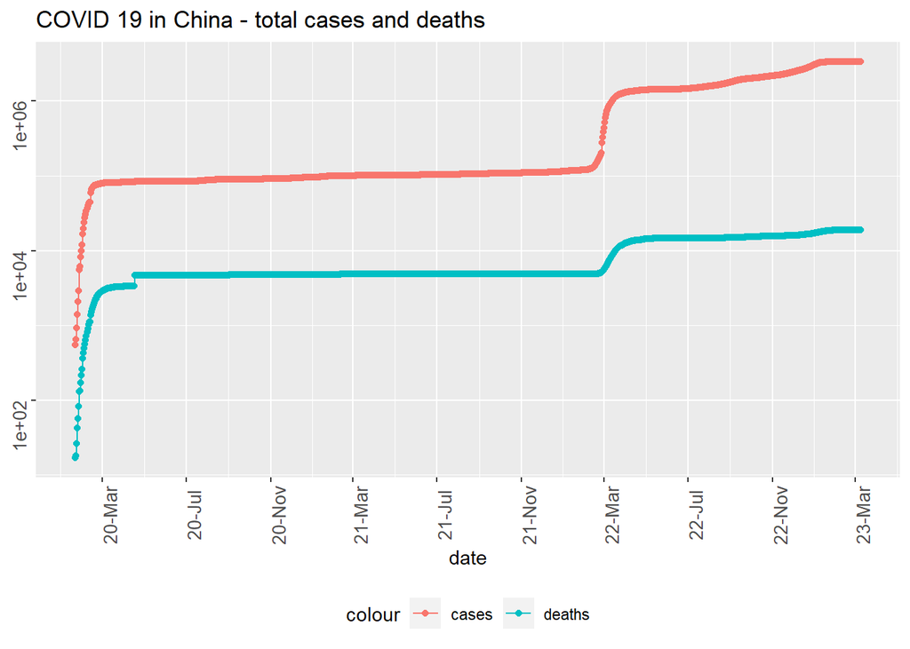

```r
# Visualize CN totals
options(repr.plot.width=30, repr.plot.height=10)
CN_totals %>%
  filter(cases>0) %>%
  ggplot(aes(x=date, y=cases))  +
  geom_line(aes(color="cases")) +
  geom_point(aes(color="cases")) +
  geom_line(aes(y=deaths, color="deaths")) +
  geom_point(aes(y=deaths, color="deaths")) +
  scale_y_log10() +
   scale_x_date(date_labels = "%y-%b", date_breaks = "4 month") +
  theme(legend.position='bottom', axis.text=element_text(angle=90, size=10)) +
  labs(title="COVID 19 in China - total cases and deaths", y=NULL)
```

## How about new cases and new deaths?

When looking at trends, it’s good to see how many new cases and new deaths. Let’s add those columns

```r
# Add new cases columns to China data
CN_by_state<- CN_by_state%>% arrange(Country_Region, Province_State, date) %>%
      mutate(new_cases=cases-lag(cases), new_deaths=deaths-lag(deaths))

CN_totals<- CN_totals%>% arrange(Country_Region, date) %>%
      mutate(new_cases=cases-lag(cases), new_deaths=deaths-lag(deaths))

# Take a look
tail(CN_by_state)
```

```
## # A tibble: 6 × 9
##   Country_Region Province_State date       cases deaths Population
##   <chr>          <chr>          <date>     <dbl>  <dbl>      <dbl>
## 1 China          Zhejiang       2023-03-04 11848      1   64567588
## 2 China          Zhejiang       2023-03-05 11848      1   64567588
## 3 China          Zhejiang       2023-03-06 11848      1   64567588
## 4 China          Zhejiang       2023-03-07 11848      1   64567588
## 5 China          Zhejiang       2023-03-08 11848      1   64567588
## 6 China          Zhejiang       2023-03-09 11848      1   64567588
## # ℹ 3 more variables: death_per_mill <dbl>, new_cases <dbl>, new_deaths <dbl>
```

```r
tail(CN_totals)
```

```
## # A tibble: 6 × 8
##   Country_Region date         cases deaths Population death_per_mill new_cases
##   <chr>          <date>       <dbl>  <dbl>      <dbl>          <dbl>     <dbl>
## 1 China          2023-03-04 3381708  18858 1417925054           13.3         0
## 2 China          2023-03-05 3381708  18859 1417925054           13.3         0
## 3 China          2023-03-06 3381708  18860 1417925054           13.3         0
## 4 China          2023-03-07 3381708  18860 1417925054           13.3         0
## 5 China          2023-03-08 3381708  18860 1417925054           13.3         0
## 6 China          2023-03-09 3381708  18861 1417925054           13.3         0
## # ℹ 1 more variable: new_deaths <dbl>
```

## Visualize new cases and deaths in China

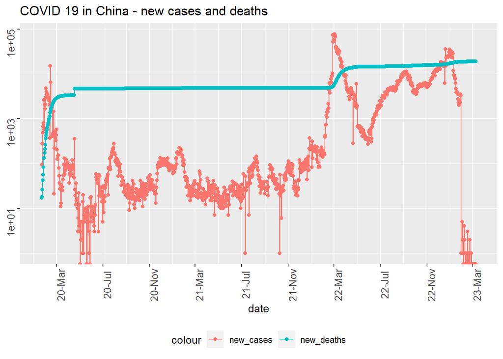

```r
# Visualize China totals
options(repr.plot.width=30, repr.plot.height=10)
CN_totals %>%
  filter(cases>0) %>%
  ggplot(aes(x=date, y=new_cases))  +
  geom_line(aes(color="new_cases")) +
  geom_point(aes(color="new_cases")) +
  geom_line(aes(y=deaths, color="new_deaths")) +
  geom_point(aes(y=deaths, color="new_deaths")) +
  scale_y_log10() +
  scale_x_date(date_labels = "%y-%b", date_breaks = "4 month") +
  theme(legend.position='bottom', axis.text=element_text(angle=90, size=10)) +
  labs(title="COVID 19 in China - new cases and deaths", y=NULL)
```

## What are the worst and best states in China?

### CN by states

Let’s see which states are best/worst (in term of death/population)

```r
CN_state_totals <- CN_by_state %>%
   group_by(Province_State) %>%
   summarize(cases=max(cases),
       deaths= max(deaths),
       Population=max(Population),
       cases_per_thou=1000*cases/Population,
       deaths_per_thou=1000*deaths/Population)
CN_state_totals %>% slice_min(deaths_per_thou,n=10)
```

```
## # A tibble: 10 × 6
##    Province_State cases deaths Population cases_per_thou deaths_per_thou
##    <chr>          <dbl>  <dbl>      <dbl>          <dbl>           <dbl>
##  1 Jiangsu         5075      0   84748016         0.0599       0
##  2 Ningxia         1276      0    7202654         0.177        0
##  3 Qinghai          782      0    5923957         0.132        0
##  4 Tibet           1647      0    3648100         0.451        0
##  5 Zhejiang       11848      1   64567588         0.183        0.0000155
##  6 Shanxi          7167      1   34915616         0.205        0.0000286
##  7 Guangxi        13371      2   50126804         0.267        0.0000399
##  8 Inner Mongolia  8847      1   24049155         0.368        0.0000416
##  9 Jiangxi         3423      2   45188635         0.0757       0.0000443
## 10 Liaoning        3547      2   42591407         0.0833       0.0000470
```

```r
CN_state_totals %>% slice_max(deaths_per_thou,n=10)
```

```
## # A tibble: 10 × 6
##    Province_State   cases deaths Population cases_per_thou deaths_per_thou
##    <chr>            <dbl>  <dbl>      <dbl>          <dbl>           <dbl>
##  1 Hong Kong      2876106  13467    7496988        384.           1.80
##  2 Macau             3547    121     649342          5.46         0.186
##  3 Hubei            72131   4515   57752557          1.25         0.0782
##  4 Shanghai         67040    595   24870895          2.70         0.0239
##  5 Beijing          40774     20   21893095          1.86         0.000914
##  6 Hainan           10483      6   10081232          1.04         0.000595
##  7 Heilongjiang      6603     18   31850088          0.207        0.000565
##  8 Chongqing        14715     11   32054159          0.459        0.000343
##  9 Henan             9948     23   99365519          0.100        0.000231
## 10 Tianjin           4392      3   13866009          0.317        0.000216
```

## visualize state of interest

I want to visualize the top 3 worst states

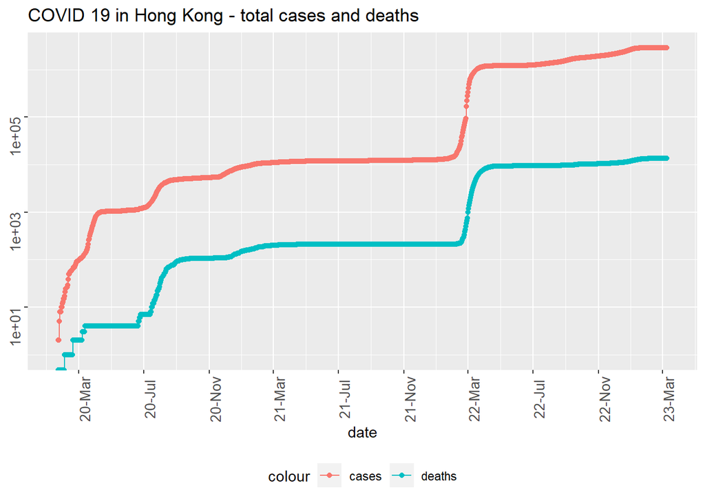

```r
state<- "Hong Kong"
CN_by_state %>%
  filter(Province_State==state) %>%
  ggplot(aes(x=date, y=cases))  +
  geom_line(aes(color="cases")) +
  geom_point(aes(color="cases")) +
  geom_line(aes(y=deaths, color="deaths")) +
  geom_point(aes(y=deaths, color="deaths")) +
  scale_y_log10() +
  scale_x_date(date_labels = "%y-%b", date_breaks = "4 month") +
  theme(legend.position='bottom', axis.text=element_text(angle=90, size=10)) +
  labs(title=str_c("COVID 19 in ", state," - total cases and deaths"), y=NULL)
```

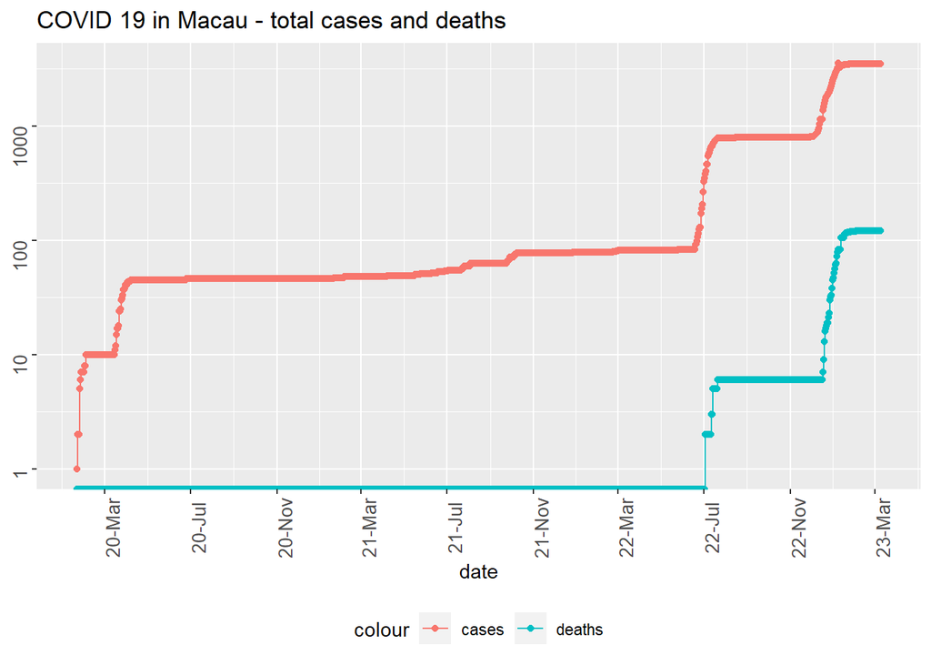

```r
state<- "Macau"
CN_by_state %>%
  filter(Province_State==state) %>%
  ggplot(aes(x=date, y=cases))  +
  geom_line(aes(color="cases")) +
  geom_point(aes(color="cases")) +
  geom_line(aes(y=deaths, color="deaths")) +
  geom_point(aes(y=deaths, color="deaths")) +
  scale_y_log10() +
  scale_x_date(date_labels = "%y-%b", date_breaks = "4 month") +
  theme(legend.position='bottom', axis.text=element_text(angle=90, size=10)) +
  labs(title=str_c("COVID 19 in ", state," - total cases and deaths"), y=NULL)
```

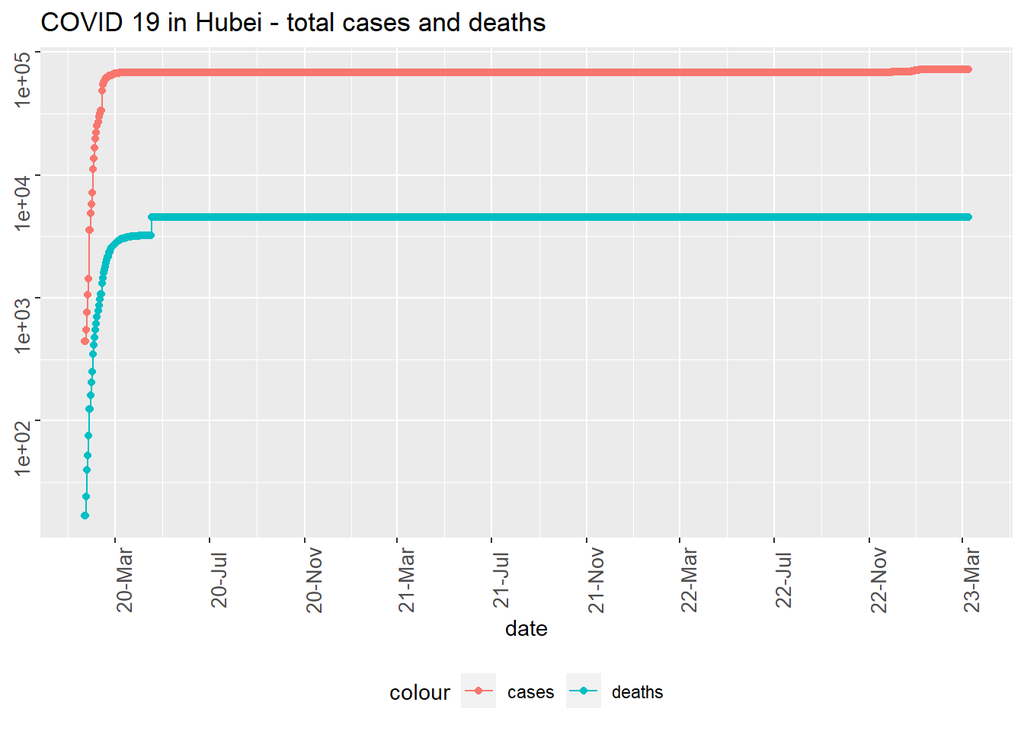

```r
state<- "Hubei"
CN_by_state %>%
  filter(Province_State==state) %>%
  ggplot(aes(x=date, y=cases))  +
  geom_line(aes(color="cases")) +
  geom_point(aes(color="cases")) +
  geom_line(aes(y=deaths, color="deaths")) +
  geom_point(aes(y=deaths, color="deaths")) +
  scale_y_log10() +
  scale_x_date(date_labels = "%y-%b", date_breaks = "4 month") +
  theme(legend.position='bottom', axis.text=element_text(angle=90, size=10)) +
  labs(title=str_c("COVID 19 in ", state," - total cases and deaths"), y=NULL)
```

## Modeling

Modeling isn’t the focus of this project. But I just want to do a couple of quick ones.

### Linear Regression

```r
# fit model
mod<-lm(deaths_per_thou ~ cases_per_thou, data = CN_state_totals)
summary(mod)
```

```
##
## Call:
## lm(formula = deaths_per_thou ~ cases_per_thou, data = CN_state_totals)
##
## Residuals:
##       Min        1Q    Median        3Q       Max
## -0.014039 -0.007515 -0.006868 -0.006497  0.154572
##
## Coefficients:
##                 Estimate Std. Error t value Pr(>|t|)
## (Intercept)    6.252e-03  5.520e-03   1.133    0.266
## cases_per_thou 4.672e-03  8.264e-05  56.531   <2e-16 ***
## ---
## Signif. codes:  0 '***' 0.001 '**' 0.01 '*' 0.05 '.' 0.1 ' ' 1
##
## Residual standard error: 0.03117 on 31 degrees of freedom
## Multiple R-squared:  0.9904, Adjusted R-squared:  0.9901
## F-statistic:  3196 on 1 and 31 DF,  p-value: < 2.2e-16
```

```r
# add predicted results column
CN_tot_w_pred <- CN_state_totals %>% mutate(pred = predict(mod))
head(CN_tot_w_pred)
```

```
## # A tibble: 6 × 7
##   Province_State  cases deaths Population cases_per_thou deaths_per_thou    pred
##   <chr>           <dbl>  <dbl>      <dbl>          <dbl>           <dbl>   <dbl>
## 1 Anhui            2275      7   61027171         0.0373       0.000115  0.00643
## 2 Beijing         40774     20   21893095         1.86         0.000914  0.0150
## 3 Chongqing       14715     11   32054159         0.459        0.000343  0.00840
## 4 Fujian          17122      2   41540086         0.412        0.0000481 0.00818
## 5 Gansu            1742      2   25019831         0.0696       0.0000799 0.00658
## 6 Guangdong      103248     10  126012510         0.819        0.0000794 0.0101
```

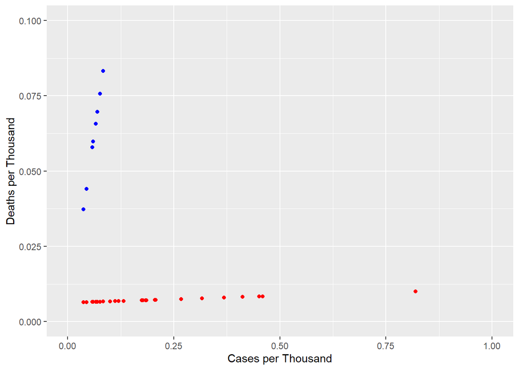

```r
# visualize results
CN_tot_w_pred %>% ggplot() +
  geom_point(aes(x = cases_per_thou, y = cases_per_thou), color = "blue") +
  geom_point(aes(x = cases_per_thou, y = pred), color = "red") +
  xlim(0,1)+
  ylim(0,0.1) +
  labs(x = "Cases per Thousand", y = "Deaths per Thousand")  # Customize axis labels
```

### KNN

```r
### fit model
mod <- train(deaths_per_thou ~ cases_per_thou, data = CN_state_totals, method = "knn")
print(mod)
```

```
## k-Nearest Neighbors
##
## 33 samples
##  1 predictor
##
## No pre-processing
## Resampling: Bootstrapped (25 reps)
## Summary of sample sizes: 33, 33, 33, 33, 33, 33, ...
## Resampling results across tuning parameters:
##
##   k  RMSE       Rsquared   MAE
##   5  0.1894335  0.5550039  0.05613163
##   7  0.1901117  0.5339927  0.05597075
##   9  0.1904916  0.5263293  0.05591486
##
## RMSE was used to select the optimal model using the smallest value.
## The final value used for the model was k = 5.
```

```r
# add predicted results column
CN_tot_w_pred <- CN_state_totals %>% mutate(pred = predict(mod))
head(CN_tot_w_pred)
```

```
## # A tibble: 6 × 7
##   Province_State  cases deaths Population cases_per_thou deaths_per_thou    pred
##   <chr>           <dbl>  <dbl>      <dbl>          <dbl>           <dbl>   <dbl>
## 1 Anhui            2275      7   61027171         0.0373       0.000115  7.18e-5
## 2 Beijing         40774     20   21893095         1.86         0.000914  2.08e-2
## 3 Chongqing       14715     11   32054159         0.459        0.000343  1.30e-4
## 4 Fujian          17122      2   41540086         0.412        0.0000481 1.30e-4
## 5 Gansu            1742      2   25019831         0.0696       0.0000799 5.49e-5
## 6 Guangdong      103248     10  126012510         0.819        0.0000794 2.13e-4
```

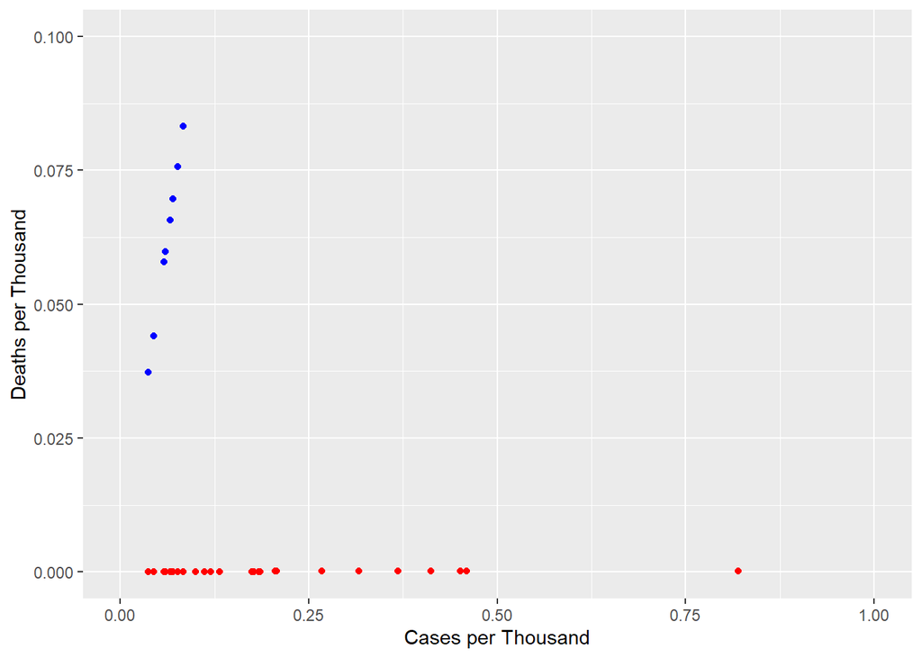

```r
# visuailze results
CN_tot_w_pred %>% ggplot() +
  geom_point(aes(x = cases_per_thou, y = cases_per_thou), color = "blue") +
  geom_point(aes(x = cases_per_thou, y = pred), color = "red") +
  xlim(0,1)+
  ylim(0,0.1) +
  labs(x = "Cases per Thousand", y = "Deaths per Thousand")  # Customize axis labels)
```

## Bias

Bias can come from different sources.

First, I want to consider the quality of data. How is data collected? Are all cases and deaths captured? Why are there some unknown states with unknown populations? Since I excluded those rows with missing population and states, the total population of China won’t be accurate.

Third, when I draw the modeling graphs, I eliminated some outliers. This may give the wrong impression of the range of deaths per thousand and cases per thousand.